# Credit Risk Analysis

**Table of Contents**

- Step 1: Import Libraries
- Step 2: Read Dataset
- Step 3: Dataset Overview
  - Step 3.1: Dataset Basic Information
  - Step 3.2: Summary Statistics for Numerical Variables
  - Step 3.3: Summary Statistics for Categorical Variables
- Step 4: Missing Value Analysis
  - Step 4.1: Indentiy missing values
  - Step 4.2: Missing Values Treatment
- Step 5: Value Standardization
- Step 6: Univariate Analysis
  - Step 6.1 : Univariate Analysis of Numerical Variables
  - Step 6.2 : Univariate Analysis of Categorical Variables
- Step 7: Correlation
- Step 8: Outliers Treatment
- Step 9: Merging Dataset
- Step 10: Bivariate Analysis
  - Step 10.1 : Categorical columns vs TARGET
  - Step 10.2 : Numerical columns vs TARGET
- Step 11: Business Oriented Conclusions

## **Business Understanding**

The aim of this analysis is to study customer data using Exploratory Data Analysis to uncover patterns, trends, and key variables that strongly influence loan default behavior. By identifying these factors, the company can make informed lending decisions, reduce the risk of default, and improve the overall effectiveness of credit risk management.

## **Step 1 : Import Libraries**

Description - In this task we import all the necessary libraries required for our project.

```python
import pandas as pd     # For data manipulation and analysis
import numpy as np      # For numrical computation
import matplotlib.pyplot as plt     # For plotting graphs and charts
import seaborn as sns       # For plotting graphs and charts in more advanced way
import math     # For mathematical operations

import warnings
warnings.filterwarnings('ignore')       # Filter out warnings to ignore them
```

## **Step 2 : Read Dataset**

```python
# Load CSV file 'application_data.csv' into a DataFrame
application_data = pd.read_csv("C:/Users/ASUS/OneDrive/Desktop/Datasets/Credit Risk Analysis Dataset/application_data.csv")
```

```python
# Clients with payment difficulties
application_data[application_data['TARGET'] == 1]
```

|  | SK_ID_CURR | TARGET | NAME_CONTRACT_TYPE | CODE_GENDER | FLAG_OWN_CAR | FLAG_OWN_REALTY | CNT_CHILDREN | AMT_INCOME_TOTAL | AMT_CREDIT | AMT_ANNUITY | ... | FLAG_DOCUMENT_18 | FLAG_DOCUMENT_19 | FLAG_DOCUMENT_20 | FLAG_DOCUMENT_21 | AMT_REQ_CREDIT_BUREAU_HOUR | AMT_REQ_CREDIT_BUREAU_DAY | AMT_REQ_CREDIT_BUREAU_WEEK | AMT_REQ_CREDIT_BUREAU_MON | AMT_REQ_CREDIT_BUREAU_QRT | AMT_REQ_CREDIT_BUREAU_YEAR |
| --- | --- | --- | --- | --- | --- | --- | --- | --- | --- | --- | --- | --- | --- | --- | --- | --- | --- | --- | --- | --- | --- |
| 0 | 100002 | 1 | Cash loans | M | N | Y | 0 | 202500.0 | 406597.5 | 24700.5 | ... | 0 | 0 | 0 | 0 | 0.0 | 0.0 | 0.0 | 0.0 | 0.0 | 1.0 |
| 26 | 100031 | 1 | Cash loans | F | N | Y | 0 | 112500.0 | 979992.0 | 27076.5 | ... | 0 | 0 | 0 | 0 | 0.0 | 0.0 | 0.0 | 0.0 | 2.0 | 2.0 |
| 40 | 100047 | 1 | Cash loans | M | N | Y | 0 | 202500.0 | 1193580.0 | 35028.0 | ... | 0 | 0 | 0 | 0 | 0.0 | 0.0 | 0.0 | 2.0 | 0.0 | 4.0 |
| 42 | 100049 | 1 | Cash loans | F | N | N | 0 | 135000.0 | 288873.0 | 16258.5 | ... | 0 | 0 | 0 | 0 | 0.0 | 0.0 | 0.0 | 0.0 | 0.0 | 2.0 |
| 81 | 100096 | 1 | Cash loans | F | N | Y | 0 | 81000.0 | 252000.0 | 14593.5 | ... | 0 | 0 | 0 | 0 | 0.0 | 0.0 | 0.0 | 0.0 | 0.0 | 0.0 |
| ... | ... | ... | ... | ... | ... | ... | ... | ... | ... | ... | ... | ... | ... | ... | ... | ... | ... | ... | ... | ... | ... |
| 307448 | 456186 | 1 | Cash loans | M | N | N | 1 | 207000.0 | 450000.0 | 32746.5 | ... | 0 | 0 | 0 | 0 | 0.0 | 0.0 | 0.0 | 0.0 | 0.0 | 2.0 |
| 307475 | 456215 | 1 | Cash loans | F | N | N | 1 | 144000.0 | 1303200.0 | 46809.0 | ... | 0 | 0 | 0 | 0 | 0.0 | 0.0 | 0.0 | 1.0 | 0.0 | 6.0 |
| 307481 | 456225 | 1 | Cash loans | M | N | Y | 0 | 225000.0 | 297000.0 | 19975.5 | ... | 0 | 0 | 0 | 0 | 0.0 | 0.0 | 0.0 | 0.0 | 0.0 | 3.0 |
| 307489 | 456233 | 1 | Cash loans | F | N | Y | 0 | 225000.0 | 521280.0 | 23089.5 | ... | 0 | 0 | 0 | 0 | 0.0 | 0.0 | 0.0 | 0.0 | 1.0 | 2.0 |
| 307509 | 456254 | 1 | Cash loans | F | N | Y | 0 | 171000.0 | 370107.0 | 20205.0 | ... | 0 | 0 | 0 | 0 | 0.0 | 0.0 | 0.0 | 0.0 | 0.0 | 0.0 |

24825 rows × 122 columns

```python
# Client with payment difficulties/other cases
application_data[application_data['TARGET'] == 0]
```

|  | SK_ID_CURR | TARGET | NAME_CONTRACT_TYPE | CODE_GENDER | FLAG_OWN_CAR | FLAG_OWN_REALTY | CNT_CHILDREN | AMT_INCOME_TOTAL | AMT_CREDIT | AMT_ANNUITY | ... | FLAG_DOCUMENT_18 | FLAG_DOCUMENT_19 | FLAG_DOCUMENT_20 | FLAG_DOCUMENT_21 | AMT_REQ_CREDIT_BUREAU_HOUR | AMT_REQ_CREDIT_BUREAU_DAY | AMT_REQ_CREDIT_BUREAU_WEEK | AMT_REQ_CREDIT_BUREAU_MON | AMT_REQ_CREDIT_BUREAU_QRT | AMT_REQ_CREDIT_BUREAU_YEAR |
| --- | --- | --- | --- | --- | --- | --- | --- | --- | --- | --- | --- | --- | --- | --- | --- | --- | --- | --- | --- | --- | --- |
| 1 | 100003 | 0 | Cash loans | F | N | N | 0 | 270000.0 | 1293502.5 | 35698.5 | ... | 0 | 0 | 0 | 0 | 0.0 | 0.0 | 0.0 | 0.0 | 0.0 | 0.0 |
| 2 | 100004 | 0 | Revolving loans | M | Y | Y | 0 | 67500.0 | 135000.0 | 6750.0 | ... | 0 | 0 | 0 | 0 | 0.0 | 0.0 | 0.0 | 0.0 | 0.0 | 0.0 |
| 3 | 100006 | 0 | Cash loans | F | N | Y | 0 | 135000.0 | 312682.5 | 29686.5 | ... | 0 | 0 | 0 | 0 | NaN | NaN | NaN | NaN | NaN | NaN |
| 4 | 100007 | 0 | Cash loans | M | N | Y | 0 | 121500.0 | 513000.0 | 21865.5 | ... | 0 | 0 | 0 | 0 | 0.0 | 0.0 | 0.0 | 0.0 | 0.0 | 0.0 |
| 5 | 100008 | 0 | Cash loans | M | N | Y | 0 | 99000.0 | 490495.5 | 27517.5 | ... | 0 | 0 | 0 | 0 | 0.0 | 0.0 | 0.0 | 0.0 | 1.0 | 1.0 |
| ... | ... | ... | ... | ... | ... | ... | ... | ... | ... | ... | ... | ... | ... | ... | ... | ... | ... | ... | ... | ... | ... |
| 307505 | 456249 | 0 | Cash loans | F | N | Y | 0 | 112500.0 | 225000.0 | 22050.0 | ... | 0 | 0 | 0 | 0 | 0.0 | 0.0 | 0.0 | 2.0 | 0.0 | 0.0 |
| 307506 | 456251 | 0 | Cash loans | M | N | N | 0 | 157500.0 | 254700.0 | 27558.0 | ... | 0 | 0 | 0 | 0 | NaN | NaN | NaN | NaN | NaN | NaN |
| 307507 | 456252 | 0 | Cash loans | F | N | Y | 0 | 72000.0 | 269550.0 | 12001.5 | ... | 0 | 0 | 0 | 0 | NaN | NaN | NaN | NaN | NaN | NaN |
| 307508 | 456253 | 0 | Cash loans | F | N | Y | 0 | 153000.0 | 677664.0 | 29979.0 | ... | 0 | 0 | 0 | 0 | 1.0 | 0.0 | 0.0 | 1.0 | 0.0 | 1.0 |
| 307510 | 456255 | 0 | Cash loans | F | N | N | 0 | 157500.0 | 675000.0 | 49117.5 | ... | 0 | 0 | 0 | 0 | 0.0 | 0.0 | 0.0 | 2.0 | 0.0 | 1.0 |

282686 rows × 122 columns

##### **Identify Target Variable**

Description - The target variabel in the dataset is 'TARGET'. It is a binary variable that indicates whether a client had difficulties to repay a loan

- 1 - The client had late payments (i.e., payment difficulties) on at least one of the first few installments
- 0 - The client had no such payment issues or other cases

##### **Check Distribution of the target variable**

Description - We check the distribution of the target variable using barplot and analyse that target variable is imbalance or not

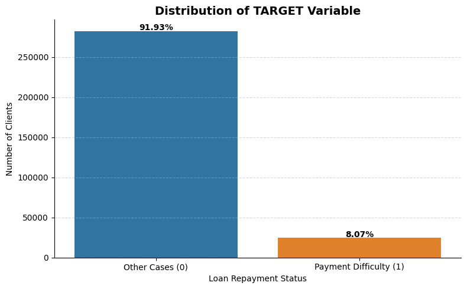

```python
# Count and percentage of target variable
target_counts = application_data['TARGET'].value_counts()
target_percent = application_data['TARGET'].value_counts(normalize=True)*100

# Create DataFrame for plotting
target_df = pd.DataFrame({
    'Label': ['Other Cases (0)', 'Payment Difficulty (1)'],
    'Count': target_counts.values,
    'Percent': target_percent.values
})

# Plotting bar charts
plt.figure(figsize=(8, 5))      # (x-axis=8, y-axis=5)
barplot = sns.barplot(data=target_df, x='Label', y='Count', hue='Label')

# For adding percentage labels on top
for index, row in target_df.iterrows():
    barplot.text(index, row['Count'] + 1000, f"{row['Percent']:.2f}%", color='black', ha='center', fontweight='bold')

plt.title("Distribution of TARGET Variable", fontsize=14, fontweight='bold')        # For graph title
plt.ylabel("Number of Clients")     # For y axis labeling
plt.xlabel("Loan Repayment Status")     # For x axis labeling
plt.grid(axis='y', linestyle='--', alpha=0.5)
sns.despine()       # For removing boxline from graph

plt.tight_layout()
plt.show()
```

- A large portion of clients belong to **Other Cases (0)**.
- A smaller portion of clients belong to **Payment Difficulty (1)**.

This shows that the dataset is imbalanced, with far fewer defaulting clients (i.e., Payment Difficulty = 1).

**What is data imbalance?**  
Data imbalance means that the classes in a variable (such as the target column) are not evenly distributed. One class (like non-defaulters) significantly outnumbers the other (like defaulters), which can lead to biased analysis or misleading results.

```python
dataset_description = pd.read_csv("C:/Users/ASUS/OneDrive/Desktop/Datasets/Credit Risk Analysis Dataset/columns_description.csv")
dataset_description
```

|  | Unnamed: 0 | Table | Row | Description | Special |
| --- | --- | --- | --- | --- | --- |
| 0 | 1 | application_data | SK_ID_CURR | ID of loan in our sample | NaN |
| 1 | 2 | application_data | TARGET | Target variable (1 - client with payment diffi... | NaN |
| 2 | 5 | application_data | NAME_CONTRACT_TYPE | Identification if loan is cash or revolving | NaN |
| 3 | 6 | application_data | CODE_GENDER | Gender of the client | NaN |
| 4 | 7 | application_data | FLAG_OWN_CAR | Flag if the client owns a car | NaN |
| ... | ... | ... | ... | ... | ... |
| 155 | 209 | previous_application.csv | DAYS_FIRST_DUE | Relative to application date of current applic... | time only relative to the application |
| 156 | 210 | previous_application.csv | DAYS_LAST_DUE_1ST_VERSION | Relative to application date of current applic... | time only relative to the application |
| 157 | 211 | previous_application.csv | DAYS_LAST_DUE | Relative to application date of current applic... | time only relative to the application |
| 158 | 212 | previous_application.csv | DAYS_TERMINATION | Relative to application date of current applic... | time only relative to the application |
| 159 | 213 | previous_application.csv | NFLAG_INSURED_ON_APPROVAL | Did the client requested insurance during the ... | NaN |

160 rows × 5 columns

## **Step 3 : Dataset Overview**

### **Step 3.1 : Dataset Basic Information**

```python
# Displaying the summary of dataframe such as non-null count, data types and memory usage
application_data.iloc[:,1:50].info() # .iloc for selecting column by index. Here we only fetch info for 1 to 49 columns
```

```
<class 'pandas.core.frame.DataFrame'>
RangeIndex: 307511 entries, 0 to 307510
Data columns (total 49 columns):
 #   Column                       Non-Null Count   Dtype
---  ------                       --------------   -----
 0   TARGET                       307511 non-null  int64
 1   NAME_CONTRACT_TYPE           307511 non-null  object
 2   CODE_GENDER                  307511 non-null  object
 3   FLAG_OWN_CAR                 307511 non-null  object
 4   FLAG_OWN_REALTY              307511 non-null  object
 5   CNT_CHILDREN                 307511 non-null  int64
 6   AMT_INCOME_TOTAL             307511 non-null  float64
 7   AMT_CREDIT                   307511 non-null  float64
 8   AMT_ANNUITY                  307499 non-null  float64
 9   AMT_GOODS_PRICE              307233 non-null  float64
```

[output cut: 41 more lines]

```python
# Displaying total number of rows and columns in dataset (rows,columns)
application_data.shape
```

```
(307511, 122)
```

```python
# Displaing columns
application_data.columns
```

```
Index(['SK_ID_CURR', 'TARGET', 'NAME_CONTRACT_TYPE', 'CODE_GENDER',
       'FLAG_OWN_CAR', 'FLAG_OWN_REALTY', 'CNT_CHILDREN', 'AMT_INCOME_TOTAL',
       'AMT_CREDIT', 'AMT_ANNUITY',
       ...
       'FLAG_DOCUMENT_18', 'FLAG_DOCUMENT_19', 'FLAG_DOCUMENT_20',
       'FLAG_DOCUMENT_21', 'AMT_REQ_CREDIT_BUREAU_HOUR',
       'AMT_REQ_CREDIT_BUREAU_DAY', 'AMT_REQ_CREDIT_BUREAU_WEEK',
       'AMT_REQ_CREDIT_BUREAU_MON', 'AMT_REQ_CREDIT_BUREAU_QRT',
       'AMT_REQ_CREDIT_BUREAU_YEAR'],
      dtype='object', length=122)
```

```python
# Displaying first five rows of the dataset to view it's structure and content
application_data.head()
```

|  | SK_ID_CURR | TARGET | NAME_CONTRACT_TYPE | CODE_GENDER | FLAG_OWN_CAR | FLAG_OWN_REALTY | CNT_CHILDREN | AMT_INCOME_TOTAL | AMT_CREDIT | AMT_ANNUITY | ... | FLAG_DOCUMENT_18 | FLAG_DOCUMENT_19 | FLAG_DOCUMENT_20 | FLAG_DOCUMENT_21 | AMT_REQ_CREDIT_BUREAU_HOUR | AMT_REQ_CREDIT_BUREAU_DAY | AMT_REQ_CREDIT_BUREAU_WEEK | AMT_REQ_CREDIT_BUREAU_MON | AMT_REQ_CREDIT_BUREAU_QRT | AMT_REQ_CREDIT_BUREAU_YEAR |
| --- | --- | --- | --- | --- | --- | --- | --- | --- | --- | --- | --- | --- | --- | --- | --- | --- | --- | --- | --- | --- | --- |
| 0 | 100002 | 1 | Cash loans | M | N | Y | 0 | 202500.0 | 406597.5 | 24700.5 | ... | 0 | 0 | 0 | 0 | 0.0 | 0.0 | 0.0 | 0.0 | 0.0 | 1.0 |
| 1 | 100003 | 0 | Cash loans | F | N | N | 0 | 270000.0 | 1293502.5 | 35698.5 | ... | 0 | 0 | 0 | 0 | 0.0 | 0.0 | 0.0 | 0.0 | 0.0 | 0.0 |
| 2 | 100004 | 0 | Revolving loans | M | Y | Y | 0 | 67500.0 | 135000.0 | 6750.0 | ... | 0 | 0 | 0 | 0 | 0.0 | 0.0 | 0.0 | 0.0 | 0.0 | 0.0 |
| 3 | 100006 | 0 | Cash loans | F | N | Y | 0 | 135000.0 | 312682.5 | 29686.5 | ... | 0 | 0 | 0 | 0 | NaN | NaN | NaN | NaN | NaN | NaN |
| 4 | 100007 | 0 | Cash loans | M | N | Y | 0 | 121500.0 | 513000.0 | 21865.5 | ... | 0 | 0 | 0 | 0 | 0.0 | 0.0 | 0.0 | 0.0 | 0.0 | 0.0 |

5 rows × 122 columns

```python
numeric = application_data.select_dtypes('number').columns
object_categorical = application_data.select_dtypes(['object', 'category']).columns
print(f'Total numbers of Numeric column: {len(numeric)}')
print(f'Total numbers of Categorical columns: {len(object_categorical)}')
```

```
Total numbers of Numeric column: 106
Total numbers of Categorical columns: 16
```

#### **Inferences:**

- **Number of entries**: The dataset consists of 307511 entries.
- **Columns**: There are 122 columns
- **Data Types**: There are total 106 numeric columns and 16 object columns

### **Step 3.2 : Summary Statistics for Numerical Variables**

```python
# Get the summary statistics for numerical variables
application_data.describe().T
```

|  | count | mean | std | min | 25% | 50% | 75% | max |
| --- | --- | --- | --- | --- | --- | --- | --- | --- |
| SK_ID_CURR | 307511.0 | 278180.518577 | 102790.175348 | 100002.0 | 189145.5 | 278202.0 | 367142.5 | 456255.0 |
| TARGET | 307511.0 | 0.080729 | 0.272419 | 0.0 | 0.0 | 0.0 | 0.0 | 1.0 |
| CNT_CHILDREN | 307511.0 | 0.417052 | 0.722121 | 0.0 | 0.0 | 0.0 | 1.0 | 19.0 |
| AMT_INCOME_TOTAL | 307511.0 | 168797.919297 | 237123.146279 | 25650.0 | 112500.0 | 147150.0 | 202500.0 | 117000000.0 |
| AMT_CREDIT | 307511.0 | 599025.999706 | 402490.776996 | 45000.0 | 270000.0 | 513531.0 | 808650.0 | 4050000.0 |
| ... | ... | ... | ... | ... | ... | ... | ... | ... |
| AMT_REQ_CREDIT_BUREAU_DAY | 265992.0 | 0.007000 | 0.110757 | 0.0 | 0.0 | 0.0 | 0.0 | 9.0 |
| AMT_REQ_CREDIT_BUREAU_WEEK | 265992.0 | 0.034362 | 0.204685 | 0.0 | 0.0 | 0.0 | 0.0 | 8.0 |
| AMT_REQ_CREDIT_BUREAU_MON | 265992.0 | 0.267395 | 0.916002 | 0.0 | 0.0 | 0.0 | 0.0 | 27.0 |
| AMT_REQ_CREDIT_BUREAU_QRT | 265992.0 | 0.265474 | 0.794056 | 0.0 | 0.0 | 0.0 | 0.0 | 261.0 |
| AMT_REQ_CREDIT_BUREAU_YEAR | 265992.0 | 1.899974 | 1.869295 | 0.0 | 0.0 | 1.0 | 3.0 | 25.0 |

106 rows × 8 columns

### **Step 3.3 : Summary Statistics for Categorical Variables**

```python
application_data.describe(include=['object']).T
```

|  | count | unique | top | freq |
| --- | --- | --- | --- | --- |
| NAME_CONTRACT_TYPE | 307511 | 2 | Cash loans | 278232 |
| CODE_GENDER | 307511 | 3 | F | 202448 |
| FLAG_OWN_CAR | 307511 | 2 | N | 202924 |
| FLAG_OWN_REALTY | 307511 | 2 | Y | 213312 |
| NAME_TYPE_SUITE | 306219 | 7 | Unaccompanied | 248526 |
| NAME_INCOME_TYPE | 307511 | 8 | Working | 158774 |
| NAME_EDUCATION_TYPE | 307511 | 5 | Secondary / secondary special | 218391 |
| NAME_FAMILY_STATUS | 307511 | 6 | Married | 196432 |
| NAME_HOUSING_TYPE | 307511 | 6 | House / apartment | 272868 |
| OCCUPATION_TYPE | 211120 | 18 | Laborers | 55186 |
| WEEKDAY_APPR_PROCESS_START | 307511 | 7 | TUESDAY | 53901 |
| ORGANIZATION_TYPE | 307511 | 58 | Business Entity Type 3 | 67992 |
| FONDKAPREMONT_MODE | 97216 | 4 | reg oper account | 73830 |
| HOUSETYPE_MODE | 153214 | 3 | block of flats | 150503 |
| WALLSMATERIAL_MODE | 151170 | 7 | Panel | 66040 |
| EMERGENCYSTATE_MODE | 161756 | 2 | No | 159428 |

## **Step 4 : Missing Values Analysis**

### **Step 4.1: Indentiy missing values**

```python
# Calculate percentage of missing values
missing_values = application_data.isnull().sum() / len(application_data) *100

# Sort the top 50 values in Descending format
missing_values = missing_values.sort_values(ascending=False)

missing_values.head(20)
```

```
COMMONAREA_AVG              69.872297
COMMONAREA_MODE             69.872297
COMMONAREA_MEDI             69.872297
NONLIVINGAPARTMENTS_MEDI    69.432963
NONLIVINGAPARTMENTS_MODE    69.432963
NONLIVINGAPARTMENTS_AVG     69.432963
FONDKAPREMONT_MODE          68.386172
LIVINGAPARTMENTS_AVG        68.354953
LIVINGAPARTMENTS_MEDI       68.354953
LIVINGAPARTMENTS_MODE       68.354953
FLOORSMIN_MODE              67.848630
FLOORSMIN_AVG               67.848630
FLOORSMIN_MEDI              67.848630
YEARS_BUILD_AVG             66.497784
YEARS_BUILD_MODE            66.497784
YEARS_BUILD_MEDI            66.497784
OWN_CAR_AGE                 65.990810
LANDAREA_MEDI               59.376738
LANDAREA_AVG                59.376738
LANDAREA_MODE               59.376738
dtype: float64
```

**As we can see many of the columns has more than 40% of missing values. Other columns has less missing values compare to this. So there is no meaning of replace the missing values because it affect our analysis. So the better way to handle this columns is just drop it. We will consider other columns for analysis.**

```python
# Include only more than 40% missing value columns
remove_missing_column = missing_values.loc[missing_values > 40].index
```

```python
# Drop the columns that has more than 40% missing values
application_data_update = application_data.drop(columns=remove_missing_column)

# columns that has missing values less than 40%
missing_values_gt_0 = application_data_update.isnull().sum()  / len(application_data) * 100
missing_values_gt_0 = missing_values_gt_0[missing_values_gt_0 > 0].sort_values(ascending=False)
missing_values_gt_0
```

```
OCCUPATION_TYPE               31.345545
EXT_SOURCE_3                  19.825307
AMT_REQ_CREDIT_BUREAU_WEEK    13.501631
AMT_REQ_CREDIT_BUREAU_MON     13.501631
AMT_REQ_CREDIT_BUREAU_YEAR    13.501631
AMT_REQ_CREDIT_BUREAU_QRT     13.501631
AMT_REQ_CREDIT_BUREAU_HOUR    13.501631
AMT_REQ_CREDIT_BUREAU_DAY     13.501631
NAME_TYPE_SUITE                0.420148
OBS_30_CNT_SOCIAL_CIRCLE       0.332021
DEF_60_CNT_SOCIAL_CIRCLE       0.332021
DEF_30_CNT_SOCIAL_CIRCLE       0.332021
OBS_60_CNT_SOCIAL_CIRCLE       0.332021
EXT_SOURCE_2                   0.214626
AMT_GOODS_PRICE                0.090403
AMT_ANNUITY                    0.003902
CNT_FAM_MEMBERS                0.000650
DAYS_LAST_PHONE_CHANGE         0.000325
dtype: float64
```

### **Step 4.2: Missing Values Treatment**

**Column 'OCCUPATION_TYPE'**

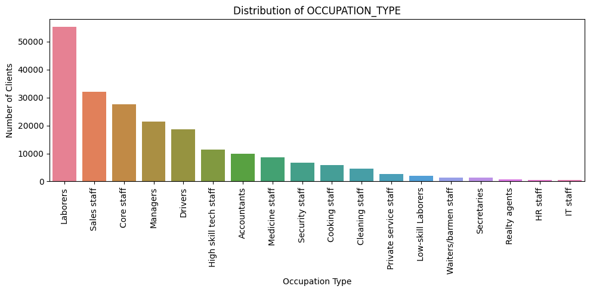

```python
# Plotting bar charts for visualization of data in easy manner

occupation_counts = application_data_update['OCCUPATION_TYPE'].value_counts().reset_index()
plt.figure(figsize=(10, 5))
sns.barplot(data=occupation_counts, x='OCCUPATION_TYPE', y='count', hue='OCCUPATION_TYPE')
plt.xticks(rotation=90)
plt.title("Distribution of OCCUPATION_TYPE")
plt.xlabel("Occupation Type")
plt.ylabel("Number of Clients")
sns.despine
plt.tight_layout()
plt.show()
```

**This column has 31% missing values so substitute with other values such as mode is not suitable in this case. Because of this reason we retain the column as it is.**

**Column 'EXT_SOURCE_3'**

```python
# print top 10 values
application_data_update['EXT_SOURCE_3'].head(10)
```

```
0    0.139376
1         NaN
2    0.729567
3         NaN
4         NaN
5    0.621226
6    0.492060
7    0.540654
8    0.751724
9         NaN
Name: EXT_SOURCE_3, dtype: float64
```

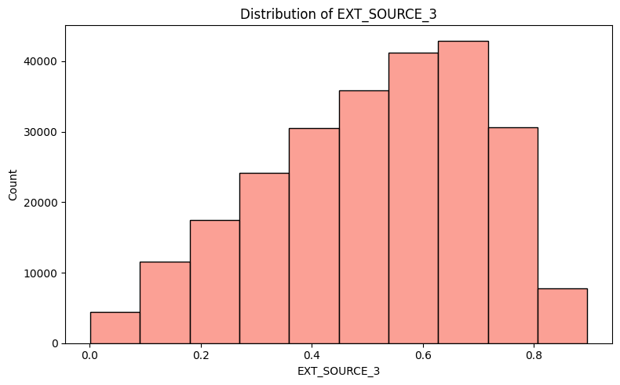

```python
# Here we use histogram to see distribution of data and frequency of data points.

plt.figure(figsize=(8,5))
plt.title("Distribution of EXT_SOURCE_3")
sns.histplot(data=application_data_update, x='EXT_SOURCE_3', bins=10, color='Salmon')
plt.tight_layout()
plt.show()
```

```python
print(f'Mean: {application_data_update['EXT_SOURCE_3'].mean()}')
print(f'Median: {application_data_update['EXT_SOURCE_3'].median()}')
print(f'Mode: {application_data_update['EXT_SOURCE_3'].mode()[0]}')
```

```
Mean: 0.5108529061799657
Median: 0.5352762504724826
Mode: 0.746300213050371
```

**The EXT_SOURCE_3 feature is a normalized external risk score ranging between 0 and 1. Higher values indicate lower credit risk. It has 19% missing data we retained the column and imputed missing values using the median. It plays a critical role in identifying risky applicants.**

```python
# Fill null values with median values
application_data_update['EXT_SOURCE_3'].fillna(application_data_update['EXT_SOURCE_3'].median(), inplace=True)
```

**Column 'AMT_REQ_CREDIT_BUREAU_WEEK'** **Description - This feature tells us how many times a bank or other lenders checked the applicant’s credit in the week before they applied for the loan.**

```python
application_data_update['AMT_REQ_CREDIT_BUREAU_WEEK'].value_counts()
```

```
AMT_REQ_CREDIT_BUREAU_WEEK
0.0    257456
1.0      8208
2.0       199
3.0        58
4.0        34
6.0        20
5.0        10
8.0         5
7.0         2
Name: count, dtype: int64
```

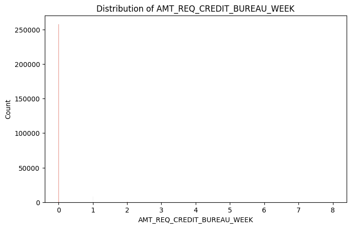

```python
# Here we use histogram to see distribution of data and frequency of data points.

plt.figure(figsize=(8,5))
plt.title("Distribution of AMT_REQ_CREDIT_BUREAU_WEEK")
sns.histplot(data=application_data_update, x='AMT_REQ_CREDIT_BUREAU_WEEK', color='Salmon')
plt.show()
```

**This shows that most clients had 0 inquiries in the last week. And most of the values are constant if we do analysis based on this column we can't get such better result for that we ignore this column.**

**Column 'AMT_REQ_CREDIT_BUREAU_MON'** **Description - This feature tells us how many times a bank or other lenders checked the applicant’s credit in the last month before they applied for the loan.**

```python
application_data_update['AMT_REQ_CREDIT_BUREAU_MON'].value_counts().head(10)
```

```
AMT_REQ_CREDIT_BUREAU_MON
0.0    222233
1.0     33147
2.0      5386
3.0      1991
4.0      1076
5.0       602
6.0       343
7.0       298
9.0       206
8.0       185
Name: count, dtype: int64
```

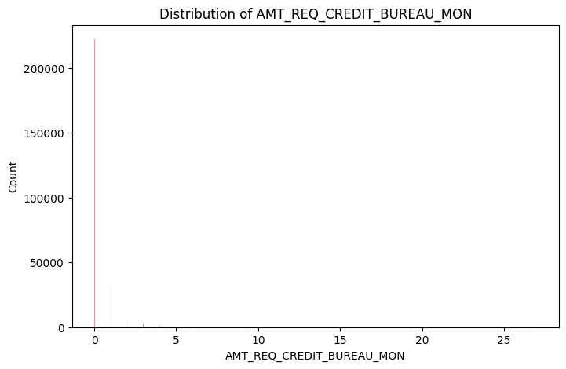

```python
# Here we use histogram to see distribution of data and frequency of data points.

plt.figure(figsize=(8,5))
plt.title("Distribution of AMT_REQ_CREDIT_BUREAU_MON")
sns.histplot(data=application_data_update, x='AMT_REQ_CREDIT_BUREAU_MON', color='Salmon')
plt.show()
```

**As same before most of the values are constant we ignore this column.**

**Column 'AMT_REQ_CREDIT_BUREAU_YEAR'** **Description - This feature tells us how many times a bank or other lenders checked the applicant’s credit in the one year before they applied for the loan.**

```python
application_data_update['AMT_REQ_CREDIT_BUREAU_YEAR'].value_counts().head(10)
```

```
AMT_REQ_CREDIT_BUREAU_YEAR
0.0    71801
1.0    63405
2.0    50192
3.0    33628
4.0    20714
5.0    12052
6.0     6967
7.0     3869
8.0     2127
9.0     1096
Name: count, dtype: int64
```

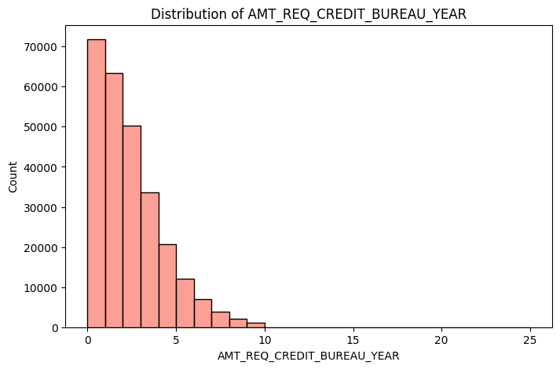

```python
# Here we use histogram to see distribution of data and frequency of data points.

plt.figure(figsize=(8,5))
plt.title("Distribution of AMT_REQ_CREDIT_BUREAU_YEAR")
sns.histplot(data=application_data_update, x='AMT_REQ_CREDIT_BUREAU_YEAR', color='Salmon', bins=25)
plt.show()
```

```python
# Calculate Average(mean) of the column
print(f'Mean: {application_data_update['AMT_REQ_CREDIT_BUREAU_YEAR'].mean()}')

# Calculate center value(median) of the column
print(f'Median: {application_data_update['AMT_REQ_CREDIT_BUREAU_YEAR'].median()}')

# Calculate most frequent value(mode) of the column
print(f'Mode: {application_data_update['AMT_REQ_CREDIT_BUREAU_YEAR'].mode()[0]}')
```

```
Mean: 1.899974435321363
Median: 1.0
Mode: 0.0
```

**As we can see from the histogram most of the data lies between 0.0 to 3.0. The column had ~13.5% missing values. Since the most common value is 0.0, indicating no inquiries in the past year, we imputed missing values with the mode. This approach is justified as it reflects the behavior of the majority and avoids introducing bias.**

```python
# Fill the missing values with mode 0.0
application_data_update['AMT_REQ_CREDIT_BUREAU_YEAR'].fillna(0.0, inplace=True)
```

**Column 'AMT_REQ_CREDIT_BUREAU_QRT'** **Description - This feature tells us how many times a bank or other lenders checked the applicant’s credit in the last three month before they applied for the loan.**

```python
application_data_update['AMT_REQ_CREDIT_BUREAU_QRT'].head(10)
```

```
0    0.0
1    0.0
2    0.0
3    NaN
4    0.0
5    1.0
6    1.0
7    0.0
8    0.0
9    NaN
Name: AMT_REQ_CREDIT_BUREAU_QRT, dtype: float64
```

```python
application_data_update['AMT_REQ_CREDIT_BUREAU_QRT'].value_counts()
```

```
AMT_REQ_CREDIT_BUREAU_QRT
0.0      215417
1.0       33862
2.0       14412
3.0        1717
4.0         476
5.0          64
6.0          28
8.0           7
7.0           7
261.0         1
19.0          1
Name: count, dtype: int64
```

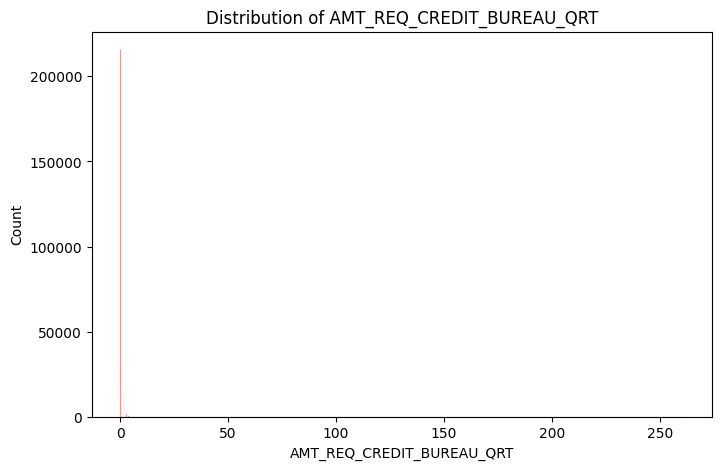

```python
# Here we use histogram to see distribution of data and frequency of data points.

plt.figure(figsize=(8,5))
plt.title("Distribution of AMT_REQ_CREDIT_BUREAU_QRT")
sns.histplot(data=application_data_update, x='AMT_REQ_CREDIT_BUREAU_QRT', color='Salmon')
plt.show()
```

**As we can see most of the values are constant and fall into one category we ignore this column.**

**Column 'AMT_REQ_CREDIT_BUREAU_HOUR'** **Description - This feature tells us how many times a bank or other lenders checked the applicant’s credit one hour before they applied for the loan.**

```python
application_data_update['AMT_REQ_CREDIT_BUREAU_HOUR'].head()
```

```
0    0.0
1    0.0
2    0.0
3    NaN
4    0.0
Name: AMT_REQ_CREDIT_BUREAU_HOUR, dtype: float64
```

```python
application_data_update['AMT_REQ_CREDIT_BUREAU_HOUR'].value_counts()
```

```
AMT_REQ_CREDIT_BUREAU_HOUR
0.0    264366
1.0      1560
2.0        56
3.0         9
4.0         1
Name: count, dtype: int64
```

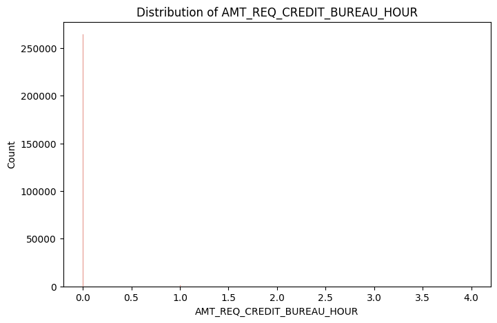

```python
# Here we use histogram to see distribution of data and frequency of data points.

plt.figure(figsize=(8,5))
plt.title("Distribution of AMT_REQ_CREDIT_BUREAU_HOUR")
sns.histplot(data=application_data_update, x='AMT_REQ_CREDIT_BUREAU_HOUR', color='Salmon')
plt.show()
```

**Again we can see most of the values are constant and fall into one category we ignore this column.**

**Column 'AMT_REQ_CREDIT_BUREAU_DAY'** **Description - This feature tells us how many times a bank or other lenders checked the applicant’s credit one day before they applied for the loan.**

```python
application_data_update['AMT_REQ_CREDIT_BUREAU_DAY'].head()
```

```
0    0.0
1    0.0
2    0.0
3    NaN
4    0.0
Name: AMT_REQ_CREDIT_BUREAU_DAY, dtype: float64
```

```python
application_data_update['AMT_REQ_CREDIT_BUREAU_DAY'].value_counts()
```

```
AMT_REQ_CREDIT_BUREAU_DAY
0.0    264503
1.0      1292
2.0       106
3.0        45
4.0        26
5.0         9
6.0         8
9.0         2
8.0         1
Name: count, dtype: int64
```

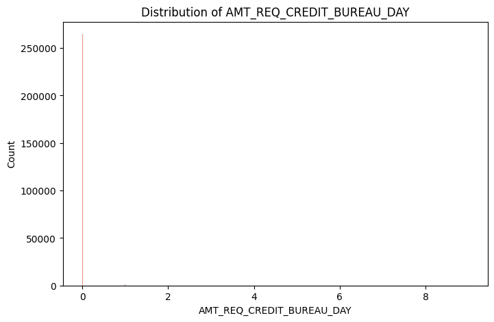

```python
# Here we use histogram to see distribution of data and frequency of data points.

plt.figure(figsize=(8,5))
plt.title("Distribution of AMT_REQ_CREDIT_BUREAU_DAY")
sns.histplot(data=application_data_update, x='AMT_REQ_CREDIT_BUREAU_DAY', color='Salmon')
plt.show()
```

**As we can see most of the values are 0 we ignore this column also**

**Column 'NAME_TYPE_SUITE'** **Description - The column describes who accompanied the client during the loan application**

```python
application_data_update['NAME_TYPE_SUITE'].head()
```

```
0    Unaccompanied
1           Family
2    Unaccompanied
3    Unaccompanied
4    Unaccompanied
Name: NAME_TYPE_SUITE, dtype: object
```

```python
application_data_update['NAME_TYPE_SUITE'].value_counts(normalize=True)*100
```

```
NAME_TYPE_SUITE
Unaccompanied      81.159562
Family             13.111205
Spouse, partner     3.713029
Children            1.066884
Other_B             0.578018
Other_A             0.282804
Group of people     0.088499
Name: proportion, dtype: float64
```

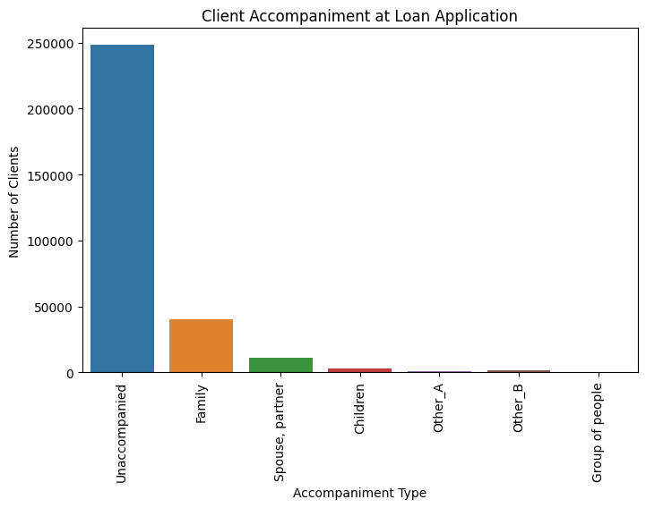

```python
# Here we leverged the used of countplot to see counts of values in each category

plt.figure(figsize=(8,5))
plt.title("Client Accompaniment at Loan Application")
sns.countplot(data=application_data_update, x='NAME_TYPE_SUITE', hue='NAME_TYPE_SUITE', legend=False)
plt.xlabel("Accompaniment Type")
plt.ylabel("Number of Clients")
plt.xticks(rotation=90)
plt.show()
```

**Most clients 81% came unaccompanied, with a smaller portion accompanied by other category. Missing values were filled with 'Unaccompanied' as mode (most frequent category.)**

```python
application_data_update['NAME_TYPE_SUITE'].mode()
```

```
0    Unaccompanied
Name: NAME_TYPE_SUITE, dtype: object
```

```python
# Fill null values with mode value
application_data_update['NAME_TYPE_SUITE'].fillna('Unaccompanied', inplace=True)
```

```python
application_data_update['OBS_30_CNT_SOCIAL_CIRCLE'].head()
```

```
0    2.0
1    1.0
2    0.0
3    2.0
4    0.0
Name: OBS_30_CNT_SOCIAL_CIRCLE, dtype: float64
```

```python
application_data_update['OBS_30_CNT_SOCIAL_CIRCLE'].value_counts().head(10)
```

```
OBS_30_CNT_SOCIAL_CIRCLE
0.0    163910
1.0     48783
2.0     29808
3.0     20322
4.0     14143
5.0      9553
6.0      6453
7.0      4390
8.0      2967
9.0      2003
Name: count, dtype: int64
```

**Columns 'OBS_30_CNT_SOCIAL_CIRCLE', 'DEF_60_CNT_SOCIAL_CIRCLE', 'DEF_30_CNT_SOCIAL_CIRCLE', 'OBS_60_CNT_SOCIAL_CIRCLE'**

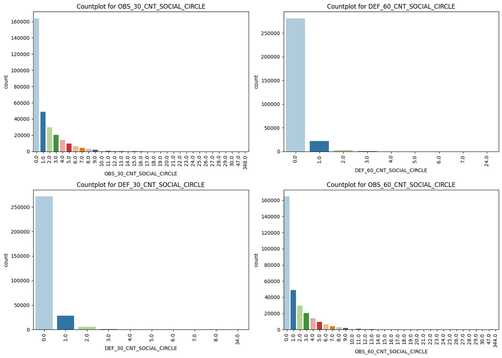

```python
# We simultaneously plot four columns becuase they are correlated with values

columns = ['OBS_30_CNT_SOCIAL_CIRCLE', 'DEF_60_CNT_SOCIAL_CIRCLE', 'DEF_30_CNT_SOCIAL_CIRCLE', 'OBS_60_CNT_SOCIAL_CIRCLE']

fig, axes = plt.subplots(2, 2, figsize=(14, 10))
axes = axes.flatten()

for idx, column in enumerate(columns):
    sns.countplot(data=application_data_update, x=column, palette='Paired', legend=False, ax=axes[idx])
    axes[idx].set_title(f'Countplot for {column}')
    axes[idx].tick_params(axis='x', rotation=90)

plt.tight_layout()
plt.show()
```

```python
# Find out correlation of below columns with Target variable

result = application_data_update[['OBS_30_CNT_SOCIAL_CIRCLE', 'DEF_30_CNT_SOCIAL_CIRCLE',
    'OBS_60_CNT_SOCIAL_CIRCLE', 'DEF_60_CNT_SOCIAL_CIRCLE', 'TARGET']].corr()
```

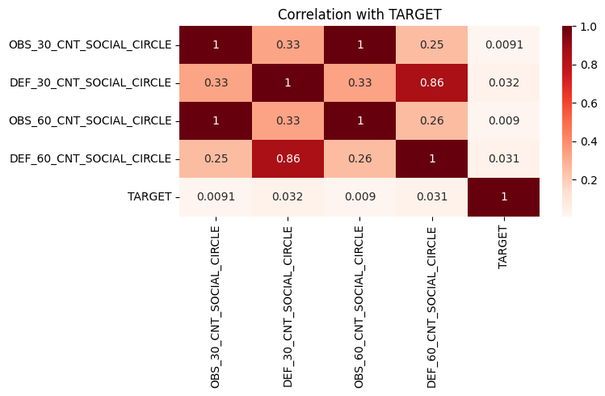

```python
# Plot correlation with heatmap

plt.figure(figsize=(8,5))
plt.title('Correlation with TARGET')
sns.heatmap(result, annot=True, cmap='Reds')
plt.tight_layout()
plt.show()
```

**As we can see from above heatmap that four columns has not strong correlation with TARGET variable and avoiding complexity we not analyse this column**

**Column 'EXT_SOURCE_2**

```python
application_data_update['EXT_SOURCE_2'].head()
```

```
0    0.262949
1    0.622246
2    0.555912
3    0.650442
4    0.322738
Name: EXT_SOURCE_2, dtype: float64
```

```python
application_data_update['EXT_SOURCE_2'].value_counts()
```

```
EXT_SOURCE_2
0.285898    721
0.262258    417
0.265256    343
0.159679    322
0.265312    306
           ...
0.353855      1
0.200589      1
0.146779      1
0.288490      1
0.269471      1
Name: count, Length: 119831, dtype: int64
```

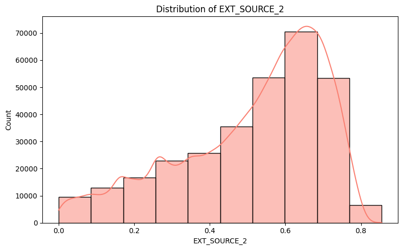

```python
# Here we use histogram to see distribution of data and frequency of data points.

plt.figure(figsize=(8,5))
plt.title("Distribution of EXT_SOURCE_2")
sns.histplot(application_data_update['EXT_SOURCE_2'], bins=10, kde=True, color='Salmon')
plt.tight_layout()
plt.show()
```

```python
print(f'Mean: {application_data_update['EXT_SOURCE_2'].mean()}')
print(f'Median: {application_data_update['EXT_SOURCE_2'].median()}')
print(f'Mode: {application_data_update['EXT_SOURCE_2'].mode()[0]}')
```

```
Mean: 0.5143926741308464
Median: 0.5659614260608526
Mode: 0.2858978721410488
```

```python
# Fill null values with median of 'EXT_SOURCE_2'
application_data_update['EXT_SOURCE_2'].fillna(application_data_update['EXT_SOURCE_3'].median(), inplace=True)
```

**Column 'AMT_GOODS_PRICE'** **Description - The column represents the price of goods for which the loan was issued.**

```python
application_data_update['AMT_GOODS_PRICE'].head()
```

```
0     351000.0
1    1129500.0
2     135000.0
3     297000.0
4     513000.0
Name: AMT_GOODS_PRICE, dtype: float64
```

```python
application_data_update['AMT_GOODS_PRICE'].value_counts()
```

```
AMT_GOODS_PRICE
450000.0     26022
225000.0     25282
675000.0     24962
900000.0     15416
270000.0     11428
             ...
1305706.5        1
2155500.0        1
113724.0         1
171468.0         1
559836.0         1
Name: count, Length: 1002, dtype: int64
```

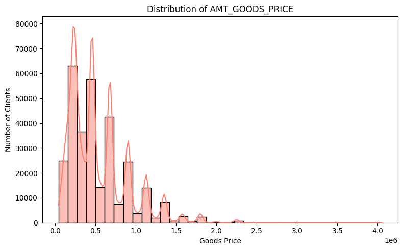

```python
# Here we use histogram to see distribution of data and frequency of data points.

plt.figure(figsize=(8, 5))
plt.title('Distribution of AMT_GOODS_PRICE')
sns.histplot(data=application_data_update, x='AMT_GOODS_PRICE', bins=35, kde=True, color='Salmon')
plt.xlabel('Goods Price')
plt.ylabel('Number of Clients')
plt.tight_layout()
plt.show()
```

**Most values are concentrated in a few specific tiers, likely reflecting standard loan packages for that reason we impute the missing values with median. This variable may provide insights when analyzed in relation to income and loan amount.**

```python
# Fill null values with median
application_data_update['AMT_GOODS_PRICE'].fillna(application_data_update['AMT_GOODS_PRICE'].median(), inplace=True)
```

**Column 'AMT_ANNUITY'** **Description - The annual payment amount required to repay the loan**

```python
application_data_update['AMT_ANNUITY'].value_counts().head(5)
```

```
AMT_ANNUITY
9000.0     6385
13500.0    5514
6750.0     2279
10125.0    2035
37800.0    1602
Name: count, dtype: int64
```

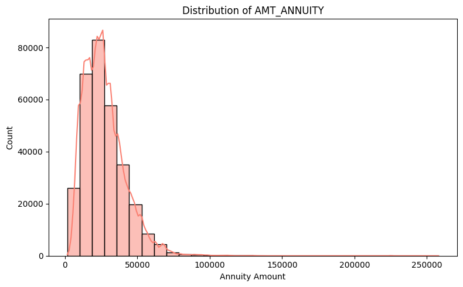

```python
# Here we use histogram to see distribution of data and frequency of data points.

plt.figure(figsize=(8, 5))
plt.title('Distribution of AMT_ANNUITY')
sns.histplot(data=application_data_update, x='AMT_ANNUITY', bins=30, kde=True, color='Salmon')
plt.xlabel('Annuity Amount')
plt.tight_layout()
plt.show()
```

**As we can from the above histogram values is cluster. We can impute the missing values with median**

```python
# Fill null values with median of 'AMT_ANNUITY'
application_data_update['AMT_ANNUITY'].fillna(application_data_update['AMT_ANNUITY'].median(), inplace=True)
```

**Column 'CNT_FAM_MEMBERS'** **Description - Number of family members client have**

```python
application_data_update['CNT_FAM_MEMBERS'].value_counts().head(5)
```

```
CNT_FAM_MEMBERS
2.0    158357
1.0     67847
3.0     52601
4.0     24697
5.0      3478
Name: count, dtype: int64
```

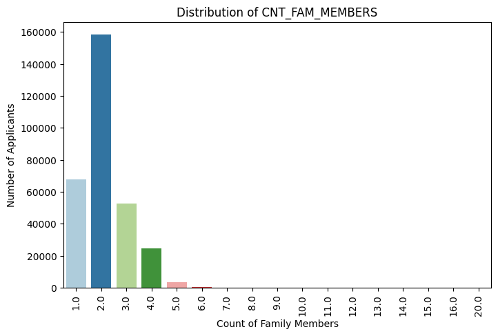

```python
# We used countplot for see category count of family members

plt.figure(figsize=(8,5))
plt.title('Distribution of CNT_FAM_MEMBERS')
sns.countplot(data=application_data_update, x='CNT_FAM_MEMBERS', palette='Paired')
plt.xlabel('Count of Family Members')
plt.ylabel('Number of Applicants')
plt.xticks(rotation=90)
plt.show()
```

**Most of the values are lies in the 2.0 and the missing values percentage of this column is 0.000650 very low. So we can impute missing values with median**

```python
# Fill null values with median
application_data_update['CNT_FAM_MEMBERS'].fillna(application_data_update['CNT_FAM_MEMBERS'].median(), inplace=True)
```

**Column 'DAYS_LAST_PHONE_CHANGE'** **Description - The day before the application client change their phone number.**

```python
application_data_update['DAYS_LAST_PHONE_CHANGE'].value_counts().head(10)
```

```
DAYS_LAST_PHONE_CHANGE
 0.0      37672
-1.0       2812
-2.0       2318
-3.0       1763
-4.0       1285
-5.0        824
-6.0        537
-7.0        442
-8.0        278
-476.0      222
Name: count, dtype: int64
```

```python
# Convert the values from days to years
application_data_update['DAYS_LAST_PHONE_CHANGE(In Year)'] = -round(application_data_update['DAYS_LAST_PHONE_CHANGE'] / 365, 0)
```

```python
# Replace -0.0 to 0.0
application_data_update['DAYS_LAST_PHONE_CHANGE(In Year)'].replace(-0.0, 0.0, inplace=True)
```

```python
application_data_update['DAYS_LAST_PHONE_CHANGE(In Year)'].value_counts()
```

```
DAYS_LAST_PHONE_CHANGE(In Year)
0.0     64176
1.0     58998
2.0     48141
4.0     34677
3.0     32321
5.0     31080
6.0     16620
7.0     12631
8.0      5300
9.0      2986
10.0      509
11.0       70
12.0        1
Name: count, dtype: int64
```

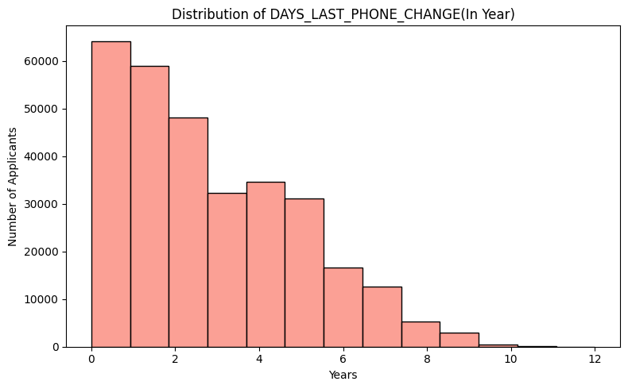

```python
# Here we use histogram to see distribution of data and frequency of data points.

plt.figure(figsize=(8,5))
plt.title('Distribution of DAYS_LAST_PHONE_CHANGE(In Year)')
sns.histplot(data=application_data_update, x='DAYS_LAST_PHONE_CHANGE(In Year)', bins=13, legend=False, color='Salmon')
plt.xlabel('Years')
plt.ylabel('Number of Applicants')
plt.tight_layout()
plt.show()
```

```python
print(f'Median: {application_data_update['DAYS_LAST_PHONE_CHANGE(In Year)'].median()}')
print(f'Mode: {application_data_update['DAYS_LAST_PHONE_CHANGE(In Year)'].mode()[0]}')
```

```
Median: 2.0
Mode: 0.0
```

**As we can see from histogram most of the data lies into the first three values (0.0, 1.0, 2.0). And the percentage of missing values is 0.000325 or we can say negligible as they not make such big impact of our analysis but for better practise we drop the missing value rows.**

```python
application_data_update = application_data_update.dropna(subset=['DAYS_LAST_PHONE_CHANGE(In Year)'])
```

```python
# check missing values percentage of dataset
(application_data_update.isnull().sum() / len(application_data_update) * 100).sort_values(ascending=False).head(20)
```

```
OCCUPATION_TYPE               31.345322
AMT_REQ_CREDIT_BUREAU_WEEK    13.501350
AMT_REQ_CREDIT_BUREAU_MON     13.501350
AMT_REQ_CREDIT_BUREAU_DAY     13.501350
AMT_REQ_CREDIT_BUREAU_QRT     13.501350
AMT_REQ_CREDIT_BUREAU_HOUR    13.501350
OBS_60_CNT_SOCIAL_CIRCLE       0.332022
OBS_30_CNT_SOCIAL_CIRCLE       0.332022
DEF_60_CNT_SOCIAL_CIRCLE       0.332022
DEF_30_CNT_SOCIAL_CIRCLE       0.332022
AMT_ANNUITY                    0.000000
AMT_CREDIT                     0.000000
AMT_INCOME_TOTAL               0.000000
CNT_CHILDREN                   0.000000
FLAG_OWN_REALTY                0.000000
FLAG_OWN_CAR                   0.000000
CODE_GENDER                    0.000000
NAME_CONTRACT_TYPE             0.000000
TARGET                         0.000000
SK_ID_CURR                     0.000000
dtype: float64
```

```python
# Drop the unnecessary columns that we not analyse
application_data_update = application_data_update.drop(columns=[
    'AMT_REQ_CREDIT_BUREAU_QRT',
    'AMT_REQ_CREDIT_BUREAU_HOUR',
    'AMT_REQ_CREDIT_BUREAU_DAY',
    'AMT_REQ_CREDIT_BUREAU_WEEK',
    'AMT_REQ_CREDIT_BUREAU_MON',
    'OBS_30_CNT_SOCIAL_CIRCLE',
    'DEF_60_CNT_SOCIAL_CIRCLE',
    'DEF_30_CNT_SOCIAL_CIRCLE',
    'OBS_60_CNT_SOCIAL_CIRCLE'
])
```

## **Step 5 : Value Standardization**

**Description - In this step we transformed columns from days to years for better readability and interpretation. We also renamed the corresponding column headers to reflect the updated units.**

```python
columns_to_change = ['DAYS_BIRTH', 'DAYS_EMPLOYED', 'DAYS_REGISTRATION', 'DAYS_ID_PUBLISH']

for column in columns_to_change:
    application_data_update[column+'(In Year)'] = -round(application_data_update[column] / 365, 0)      # change days to year by diving it 365 and create new columns
```

```python
# Here we drop the unnecessary columns that are not relevent to our analysis
application_data_update = application_data_update.drop(columns=[
    'DAYS_BIRTH',
    'DAYS_EMPLOYED',
    'DAYS_REGISTRATION',
    'DAYS_ID_PUBLISH',
    'DAYS_LAST_PHONE_CHANGE'
])
```

## **Step 6 : Univariate Analysis**

We undertake univariate analysis on the dataset's features, based on their datatype:

- For **numerical/continuous data**: We employ histograms to gain insight into the distribution of each feature. This allows us to understand the central tendency, spread, and shape of the dataset's distribution.
- For **categorical data**: Bar plots are utilized to visualize the frequency of each category. This provides a clear representation of the prominence of each category within the respective feature.

By employing these visualization techniques, we're better positioned to understand the individual characteristics of each feature in the dataset.

### **Step 6.1 : Univariate Analysis of Numerical Variables**

```python
numeric_columns = application_data_update.select_dtypes(include=['number'])
columns = numeric_columns.columns
```

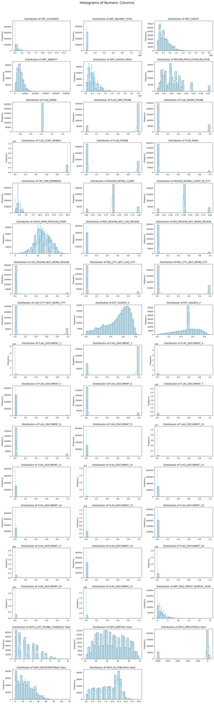

```python
# Plot histograms in subplots
cols = 3
rows = int(np.ceil(len(columns) / cols))
fig, axes = plt.subplots(rows, cols, figsize=(16, rows * 3))
axes = axes.flatten()

for i, col in enumerate(columns[2:]):
    sns.histplot(numeric_columns[col], kde=True, bins=30, color='skyblue', ax=axes[i])
    axes[i].set_title(f'Distribution of {col}')
    axes[i].set_xlabel('')
    axes[i].set_ylabel('Frequency')

# Remove unused subplots
for j in range(i + 1, len(axes)):
    fig.delaxes(axes[j])

plt.tight_layout()
plt.suptitle("Histograms of Numeric Columns", fontsize=18, y=1.02)
plt.show()
```

### **Step 6.2 : Univariate Analysis of Categorical Variables**

```python
categorical_columns = application_data_update.select_dtypes(include=['object'])
cat_columns = categorical_columns.columns
```

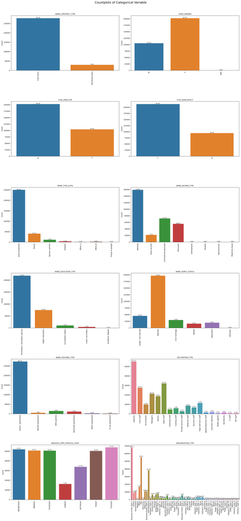

```python
# With the help of countplot we analyse the categorical variables


# Number of rows and columns for subplots
cols = 2
rows = math.ceil(len(cat_columns) / cols)

# Plot setup with subplots
fig, axes = plt.subplots(rows, cols, figsize=(20, rows * 7))
axes = axes.flatten()

# Plot countplot
for i, col in enumerate(cat_columns):
    ax = axes[i]
    total = categorical_columns[col].notna().sum()
    sns.countplot(data=categorical_columns, x=col, ax=ax, hue=col, legend=False)
    ax.set_title(col, fontsize=10)
    ax.tick_params(axis='x', rotation=90)
    ax.set_xlabel('')
    ax.set_ylabel('Count')

    # Add % labels on top of bar
    for p in ax.patches:
        count = int(p.get_height())
        percentage = 100 * count / total
        ax.text(p.get_x() + p.get_width()/2., p.get_height() + 500,
                f'{percentage:.1f}%', ha='center', fontsize=8)

# Remove unused axes
for j in range(i + 1, len(axes)):
    fig.delaxes(axes[j])

plt.tight_layout()
plt.suptitle('Countplots of Categorical Variable', fontsize=18, y=1.02)
plt.show()
```